# Customer Churn Data

Samer Alzaim

# 1 Introduction

- *Customers Churn Data* - The dataset collect customers information and attempt to identify drivers of customers attrition for telecommunication company.
- *Data Collection Process* - Process of generating the data is unknown,however, it is most likely collected from a telecommunication company database.

# 2 Description of Data

- *Data Structure* - dataset contains 1000 observations with 14 categorical and numerical variables.
- *Itemized List of Feature Variables*:
- Variable 1: Sex (Categorical)
- Variable 2: Marital_Status (Categorical)
- Variable 3: Term (displayed in months-(Numeric))
- Variable 4: Phone_service (Yes – Have phone service, No – Does not have phone service – (Categorical))
- Variable 5: International_plan (Yes – Have international plan, No – Does not have phone service – (Categorical))
- Variable 6: Voice_mail_plan (Yes – Have voice mail plan, No – Does not have voice mail plan – (Categorical))
- Variable 7: Multiple_line (Yes – Have multiple line, No – Does not have multiple line, No phone – Does not have Phone service – (Categorical))
- Variable 8:Internet_service (Type of internet service Cable, Fibre optic, DSL, No internet- (Categorical))
- Variable 9: Technical_support (Yes – Have technical support, No – Does not have technical support, No internet – Does not have internet service – (Categorical))
- Variable 10:Streaming_Videos (Yes – Have technical support,No – Does not have technical support, No internet – Does not have internet service – (Categorical))
- Variable 11: Agreement_period (Type of contract like monthly contract, one year contract and two year contract (Categorical))
- Variable 12: Monthly_Charges (Numeric)
- Variable 13: Total_Charges (Numeric)
- Variable 14: Churn (Yes - customer churn ,No - customer not churn (categorical))

```r
data <- read.table("https://pengdsci.github.io/datasets/ChurnData/Customer-Chrn-dataset.txt",
                   header = TRUE, sep = ",", stringsAsFactors = FALSE)
```

# 3 Data Analysis

## 3.1 Missing values

No missing values in the data set.

```r
sum(is.na(data))  # Returns the total number of missing values
```

```
[1] 0
```

## 3.2 Accounts Distribution

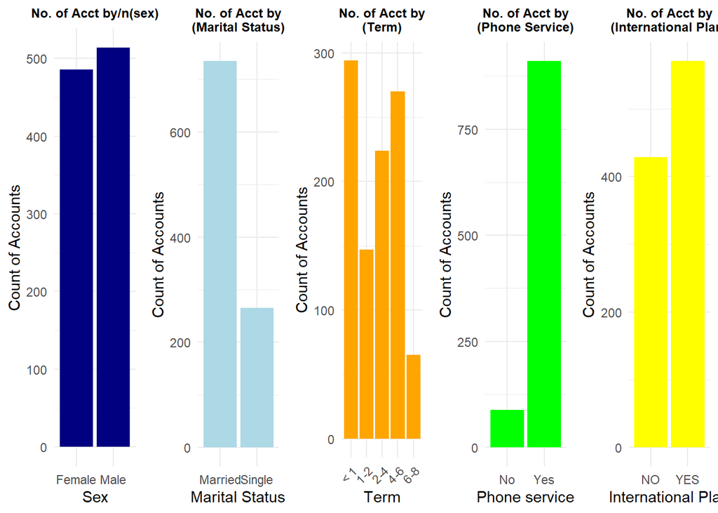

```r
library(gridExtra)  # Load the package before using grid.arrange()



# Create bar plot for Sex
sex_plot <- ggplot(data, aes(x = Sex, fill = sex)) +
  geom_bar(fill = "navy") +
  labs(title = "No. of Acct by/n(sex)",
       x = "Sex",
       y = "Count of Accounts") +
  theme_minimal() +
  theme(plot.title = element_text(size = 9, face = "bold", hjust = 0.5), legend.position = "none")  # Remove redundant legend

# Create bar plot for Marital Status
mrt_plot <- ggplot(data, aes(x = Marital_Status, fill = Marital_Status)) +
  geom_bar(fill = "lightblue") +
  labs(title = "No. of Acct by\n(Marital Status)",
       x = "Marital Status",
       y = "Count of Accounts") +
  theme_minimal() +
  theme(plot.title = element_text(size = 9, face = "bold", hjust = 0.5), legend.position = "none")  # Remove redundant legend


# Group Terms into bins
data <- data %>%
  mutate(Term = cut(Term,
                            breaks = c(0, 12, 24, 48, 72, 96, Inf),
                            labels = c("< 1", "1-2", "2-4", "4-6", "6-8", "8+"),
                            right = FALSE))  # Right = FALSE means 24 is in "12-24"
# Create bar plot for Term
term_plot <- ggplot(data, aes(x = Term, fill = Term)) +
  geom_bar(fill = "orange") +
  labs(title = "No. of Acct by\n(Term)",
       x = "Term",
       y = "Count of Accounts") +
  theme_minimal() +
  theme(plot.title = element_text(size = 9, face = "bold", hjust = 0.5), axis.text.x = element_text(angle = 45, vjust = 1, hjust = 1), legend.position = "none")  # Remove redundant legend

# Create bar plot for No. of Phone service
phone_plot <- ggplot(data, aes(x = Phone_service, fill = Phone_service)) +
  geom_bar(fill = "green") +
  labs(title = "No. of Acct by\n(Phone Service)",
       x = "Phone service",
       y = "Count of Accounts") +
  theme_minimal() +
  theme(plot.title = element_text(size = 9, face = "bold", hjust = 0.5), legend.position = "none")  # Remove redundant legend

# Convert all categorical values into upper case
data$International_plan <- toupper(data$International_plan)  # Convert all to lowercase

# Create bar plot for International plan
Int_plot <- ggplot(data, aes(x = International_plan, fill = International_plan)) +
  geom_bar(fill = "yellow") +
  labs(title = "No. of Acct by\n(International Plan)",
       x = "International Plan",
       y = "Count of Accounts") +
  theme_minimal() +
  theme(plot.title = element_text(size = 9, face = "bold", hjust = 0.5), legend.position = "none")  # Remove redundant legend

# Arrange the three plots side by side

grid.arrange(sex_plot, mrt_plot, term_plot,phone_plot, Int_plot, ncol = 5)
```

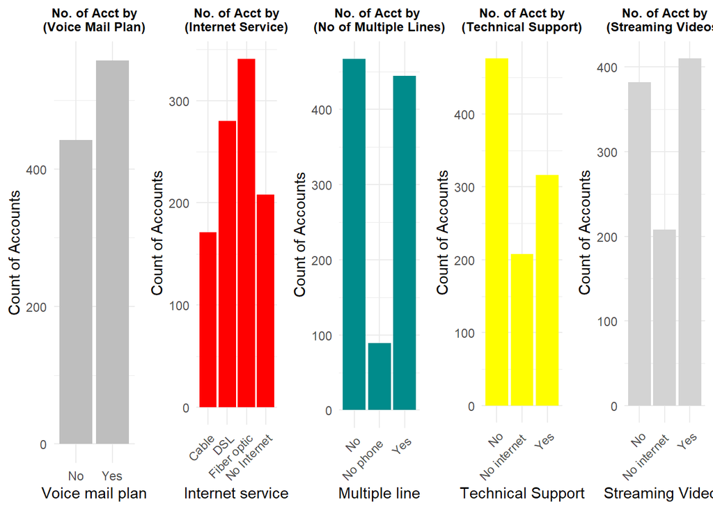

```r
library(gridExtra)  # Load the package before using grid.arrange()

# Create bar plot for Voice mail plan
voice_plot <- ggplot(data, aes(x = Voice_mail_plan, fill = Voice_mail_plan)) +
  geom_bar(fill = "gray") +
  labs(title = "No. of Acct by\n(Voice Mail Plan)",
       x = "Voice mail plan",
       y = "Count of Accounts") +
  theme_minimal() +
  theme(plot.title = element_text(size = 9, face = "bold", hjust = 0.5),  legend.position = "none", legend.direction = "vertical")  # Remove redundant legend


# Create bar plot for Internet service
internet_plot <- ggplot(data, aes(x = Internet_service, fill = Internet_service)) +
  geom_bar(fill = "red") +
  labs(title = "No. of Acct by\n(Internet Service)",
       x = "Internet service",
       y = "Count of Accounts") +
  theme_minimal() +
  theme(plot.title = element_text(size = 9, face = "bold", hjust = 0.5), axis.text.x = element_text(angle = 45, vjust = 1, hjust = 1), legend.position = "none")  # Remove redundant legend

# Create bar plot for No. of Multiple_line
multiple_plot <- ggplot(data, aes(x = Multiple_line, fill = Multiple_line)) +
  geom_bar(fill = "cyan4") +
  labs(title = "No. of Acct by \n(No of Multiple Lines)",
       x = "Multiple line",
       y = "Count of Accounts") +
  theme_minimal() +
  theme(plot.title = element_text(size = 9, face = "bold", hjust = 0.5), axis.text.x = element_text(angle = 45, vjust = 1, hjust = 1), legend.position = "none")  # Remove redundant legend


# Create bar plot for Technical support
tech_plot <- ggplot(data, aes(x = Technical_support, fill = Technical_support)) +
  geom_bar(fill = "yellow") +
  labs(title = "No. of Acct by\n(Technical Support)",
       x = "Technical Support",
       y = "Count of Accounts") +
  theme_minimal() +
  theme(plot.title = element_text(size = 9, face = "bold", hjust = 0.5), axis.text.x = element_text(angle = 45, vjust = 1, hjust = 1),legend.position = "none")  # Remove redundant legend

# Create bar plot for Streaming Videos
video_plot <- ggplot(data, aes(x = Streaming_Videos, fill = Streaming_Videos)) +
  geom_bar(fill = "#D3D3D3") +
  labs(title = "No. of Acct by\n(Streaming Videos)",
       x = "Streaming Videos",
       y = "Count of Accounts") +
  theme_minimal() +
  theme(plot.title = element_text(size = 9, face = "bold", hjust = 0.5),  axis.text.x = element_text(angle = 45, vjust = 1, hjust = 1), legend.position = "none")  # Remove redundant legend

# Arrange the three plots side by side

grid.arrange(voice_plot, internet_plot,multiple_plot, tech_plot, video_plot, ncol = 5)
```

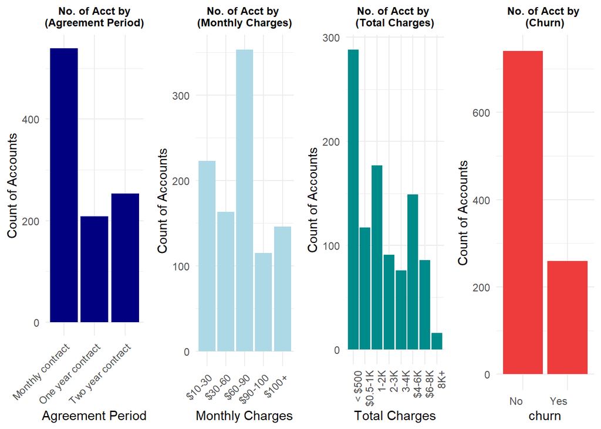

```r
library(gridExtra)  # Load the package before using grid.arrange()

# Create bar plot for Agreement_period
agreement_plot <- ggplot(data, aes(x = Agreement_period, fill = Agreement_period)) +
  geom_bar(fill = "navy") +
  labs(title = "No. of Acct by\n(Agreement Period)",
       x = "Agreement Period",
       y = "Count of Accounts") +
  theme_minimal() +
  theme(plot.title = element_text(size = 9, face = "bold", hjust = 0.5), axis.text.x = element_text(angle = 45, vjust = 1, hjust = 1), legend.position = "none")  # Remove redundant legend

# group Monthly_Charges
data <- data %>%
  mutate(Monthly_Charges = cut(Monthly_Charges,
                            breaks = c(0, 10, 30, 60, 90, 100, Inf),
                            labels = c("< $10", "$10-30", "$30-60", "$60-90", "$90-100", "$100+"),
                            right = FALSE))  # Right = FALSE means 24 is in "12-24"

# Create bar plot for No. of Monthly_Charges
charges_plot <- ggplot(data, aes(x = Monthly_Charges, fill = Monthly_Charges)) +
  geom_bar(fill = "lightblue") +
  labs(title = "No. of Acct by \n(Monthly Charges)",
       x = "Monthly Charges",
       y = "Count of Accounts") +
  theme_minimal() +
  theme(plot.title = element_text(size = 9, face = "bold", hjust = 0.5), axis.text.x = element_text(angle = 45, vjust = 1, hjust = 1), legend.position = "none")  # Remove redundant legend

# Create bar plot for No. of Total_Charges

data <- data %>%
  mutate(Total_Charges = cut(Total_Charges,
                            breaks = c(0, 500, 1000, 2000, 3000, 4000, 6000, 8000, Inf),
                            labels = c("< $500", "$0.5-1K", "1-2K", "2-3K", "3-4K",  "$4-6K", "$6-8K",  "8K+" ),
                            right = FALSE))  # Right = FALSE means 24 is in "12-24"

total_plot <- ggplot(data, aes(x = Total_Charges, fill = Total_Charges)) +
  geom_bar(fill = "cyan4") +
  labs(title = "No. of Acct by \n(Total Charges)",
       x = "Total Charges",
       y = "Count of Accounts") +
  theme_minimal() +
  theme(plot.title = element_text(size = 9, face = "bold", hjust = 0.5), axis.text.x = element_text(angle = 90, vjust = 1, hjust = 1), legend.position = "none")  # Remove redundant legend



# Create bar plot for No. of Churn
churn_plot <- ggplot(data, aes(x = Churn, fill = Churn)) +
  geom_bar(fill = "brown2") +
  labs(title = "No. of Acct by \n(Churn)",
       x = "churn",
       y = "Count of Accounts") +
  theme_minimal() +
  theme(plot.title = element_text(size = 9, face = "bold", hjust = 0.5), axis.text.x = element_text( vjust = 1, hjust = 1), legend.position = "none")  # Remove redundant legend


# Arrange the three plots side by side

grid.arrange( agreement_plot,charges_plot, total_plot, churn_plot, ncol = 4)
```

## 3.3 Account Ditribution by Churn

When looking at the distribution by number of churn accounts across all variables, we can see that accounts with monthly charges have much higher portion of churn accounts compared to accounts with yearly and 2 yearly contracts.

Similarly, we can see that accounts with Fiber Optic internet service have higher churn portion compared to other internet services.

No clear separation can be seen between accounts based on number of line, sex, having phone service, voice mail plan or streaming videos.

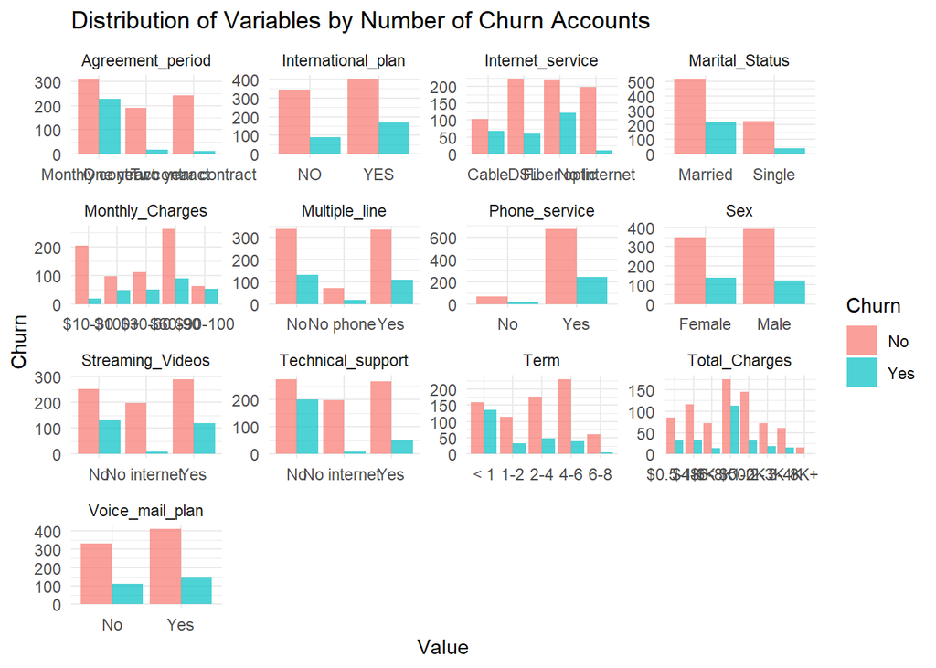

```r
ldd_long <- data %>%
  mutate(across(everything(), as.character)) %>%  # Convert all columns to character
  pivot_longer(cols = -Churn, names_to = "Variable", values_to = "Value")

# Generate distribution plots for each variable by Churn
ggplot(ldd_long, aes(x = Value, fill = as.factor(Churn))) +
  geom_bar(alpha = 0.7, position = "dodge") +  # Bar plot for categorical values
  facet_wrap(~ Variable, scales = "free") +  # Separate plots for each variable
  labs(title = "Distribution of Variables by Number of Churn Accounts",
       x = "Value",
       y = "Churn",
       fill = "Churn") +
  theme_minimal()
```

# 4 Regularize Logestic Regression Model

## 4.1 Coefficient Path Analysis

We utilize the coefficient path and measures of fit as they are essential tools for understanding model performance and selecting the optimal regularization parameter.

A larger value of λ can lead to potential underfitting, as more coefficients are shrunk toward zero, resulting in a larger error (right panel).

A smaller value of λ can lead to potential overfitting, as fewer coefficients are shrunk, allowing more to remain in the model, which results in a smaller error.

based on the above, looking at the 2 graphs below we can see that our optimal lambda, the red and the blue vertical lines in the left graph between 4 and 8 corresponding to Log Lambda between -3 and -5. This also substantiated from the right graph where we can see that our Deviance is lower between these 2 lines while on moving to the left of the x axis would not generate meaningful drop in deviance.

```r
# Convert Churn to binary (1 = Yes, 0 = No)
data$Churn <- ifelse(data$Churn == "Yes", 1, 0)
data$Churn <- as.numeric(data$Churn)  # Ensure numeric type

# Set seed for reproducibility
set.seed(123456)

# Prepare features (X) and target (y)
X <- data[, colnames(data) != "Churn"]  # Exclude Churn column
y <- data$Churn

# Split the data into training and testing sets
train_index <- createDataPartition(y, p = 0.8, list = FALSE)
X_train <- X[train_index, ]
X_test <- X[-train_index, ]
y_train <- y[train_index]
y_test <- y[-train_index]

# Convert X_train and X_test to numeric matrices
X_train <- data.matrix(X_train)
X_test <- data.matrix(X_test)

# Convert X_train and X_test to numeric matrices (required for glmnet)
X_train <- data.matrix(X_train)
X_test <- data.matrix(X_test)

# ✅ Fit Logistic Regression Models with Regularization

## LASSO (L1 Regularization)
lasso_model <- glmnet(X_train, y_train, family = "binomial", alpha = 1)

## Ridge (L2 Regularization)
fit_ridge <- glmnet(X_train, y_train, family = "binomial", alpha = 0)

## Elastic Net (Mix of L1 & L2)
fit_elastic_net <- glmnet(X_train, y_train, family = "binomial", alpha = 0.5)

# ✅ Cross-validation to find best lambda
cv_lasso <- cv.glmnet(X_train, y_train, family = "binomial", alpha = 1)
cv_ridge <- cv.glmnet(X_train, y_train, family = "binomial", alpha = 0)
cv_elastic <- cv.glmnet(X_train, y_train, family = "binomial", alpha = 0.5)

# Best lambda for LASSO
best_lambda_lasso <- cv_lasso$lambda.min
print(best_lambda_lasso)
```

```
[1] 0.008778758
```

```r
# Optimal lambda Lasso
lambda_lasso <- cv_lasso$lambda.min

# Refit the model with the optimal lambda
lasso_model_opt <- glmnet(X_train, y_train, family = "binomial", alpha = 1, lambda = lambda_lasso)

# Optimal lambda Ridge
lambda_ridge <- cv_ridge$lambda.min

# Refit the model with the optimal lambda
ridge_model_opt <- glmnet(X_train, y_train,
                          family = "binomial",
                          alpha = 0,
                          lambda = lambda_ridge)


# Optimal lambda Elastic
lambda_elastic <- cv_elastic$lambda.min

# Refit the model with the optimal lambda
elastic_model_opt <- glmnet(X_train, y_train,
                            family = "binomial",
                            alpha = 0.5,
                            lambda = lambda_elastic)
```

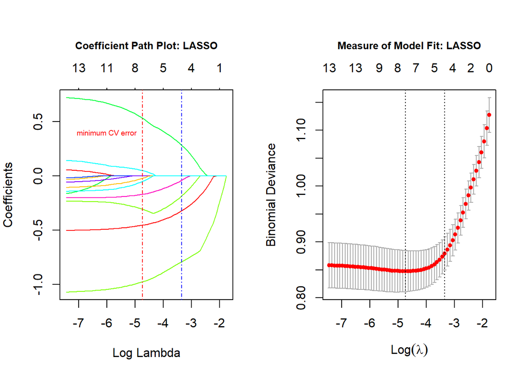

```r
## Visualize the impact of lambda on shrinking coefficients
# Plot coefficient paths
par(mar=c(5,4,6,2), mfrow=c(1,2)) #
plot(lasso_model, xvar = "lambda", label = TRUE,
     col = rainbow(8),
     lwd = 1,
     main = "Coefficient Path Plot: LASSO",
     cex.main = 0.8)
text(-6, 0.4, "minimum CV error", col="red", cex = 0.6 )
abline(v = log(cv_lasso$lambda.min), col = "red", lty = 4, lwd = 1)
abline(v = log(cv_lasso$lambda.1se), col = "blue", lty = 4, lwd = 1)

plot(cv_lasso, main="Measure of Model Fit: LASSO", cex.main = 0.8)
```

## 4.2 Regularization Parameter Determination

To avoid potential issues of over fitting and underfitting, a cross-validation was used to provide a range of suggested value for the regularization parameter λ.

we can see from the table below that ridge utilizes all variable leading potentially to overfitting, while lasso and elastic approaches, have lower number of variables.

```r
lasso.coef <- as.matrix(coef(lasso_model_opt))
ridge.coef <- as.matrix(coef(ridge_model_opt))
elastic.coef <- as.matrix(coef(elastic_model_opt))
regularized.coef <- data.frame(lasso = lasso.coef[,1],
                               ridge = ridge.coef[,1],
                          elasticnet = elastic.coef[,1])
pander(regularized.coef)
```

|  | lasso | ridge | elasticnet |
| --- | --- | --- | --- |
| **(Intercept)** | 0.287 | 0.82 | 0.466 |
| **Sex** | 0 | 0.04443 | 0 |
| **Marital_Status** | 0 | -0.2599 | -0.1003 |
| **Term** | -0.3019 | -0.2654 | -0.2803 |
| **Phone_service** | 0 | -0.09926 | 0 |
| **International_plan** | 0.04744 | 0.1413 | 0.06209 |
| **Voice_mail_plan** | 0 | -0.01918 | 0 |
| **Multiple_line** | 0 | -0.02712 | 0 |
| **Internet_service** | -0.1696 | -0.2115 | -0.1803 |
| **Technical_support** | -0.4543 | -0.4815 | -0.4564 |
| **Streaming_Videos** | -0.02269 | -0.05364 | -0.01543 |
| **Agreement_period** | -0.9756 | -0.8303 | -0.8848 |
| **Monthly_Charges** | 0.5325 | 0.5109 | 0.4876 |
| **Total_Charges** | -0.05446 | -0.1024 | -0.07079 |

## 4.3 Optimal Cut0ff Probability Determination

```r
#############################
# Predict on the test set: type = "class" uses the default
# cut-off probability to be 0.5.
predict_lasso <- predict(lasso_model_opt, newx = X_test, type = "response")
predict_ridge <- predict(ridge_model_opt, newx = X_test, type = "response")
predict_elastic <- predict(elastic_model_opt, newx = X_test, type = "response")

###########################################
## Optimal cutoff probability determination
seq.cut <- seq(0,1, length=50)
# y is a vector of 0 and 1
acc.lasso <- NULL
acc.ridge <- NULL
acc.elastic <- NULL
for (i in 1:length(seq.cut)){
   predy.lasso <- ifelse(predict_lasso >seq.cut[i], 1, 0)
   predy.ridge<- ifelse(predict_ridge >seq.cut[i], 1, 0)
   predy.elastic<- ifelse(predict_elastic >seq.cut[i], 1, 0)
   ##
   acc.lasso[i] <- mean(y_test  == predy.lasso)
   acc.ridge[i] <- mean(y_test == predy.ridge)
   acc.elastic[i] <- mean(y_test  == predy.elastic)
}
## optimal cut-off: if the maximum accuracy occurs at multiple
## cut-off probabilities, the average of these cutoff probabilities
## will be defined as the optimal cutoff probability
opt.cut.lasso <- mean(seq.cut[which(acc.lasso==max(acc.lasso))])
opt.cut.ridge<- mean(seq.cut[which(acc.ridge==max(acc.ridge))])
opt.cut.elastic <- mean(seq.cut[which(acc.elastic==max(acc.elastic))])
##
acc.data <- data.frame(prob = rep(seq.cut,3),
                       acc=c(acc.lasso, acc.ridge, acc.elastic),
                       group = c(rep("lasso",50), rep("ridge",50), rep("elastic",50)))
```

```r
##
gg.acc <- ggplot(data = acc.data, aes(x=prob, y = acc, color = group)) +
  geom_line() +
  annotate("text", x = 0.6, y = 0.45,
           label = paste("LASSO cutoff: ", round(opt.cut.lasso,5), "Accuracy: ", round(max(acc.lasso),5),
                         "\nRidge cutoff: ", round(opt.cut.ridge,5), "Accuracy: ", round(max(acc.ridge),5),
                         "\nElastic cutoff: ", round(opt.cut.elastic,5), "Accuracy: ", round(max(acc.elastic),5)),
           size = 3,
           color = "navy") +
  ggtitle("Cut-off Probability vs Accuracy") +
  labs(x = "cut-off Probability",
       y = "accuracy", color = "Group") +
  theme(plot.title = element_text(hjust = 0.5))

##
ggplotly(gg.acc)
```

[interactive chart not shown]

the table below show the key statistics for all 3 methods. the data are very close to each others for example ridge and elastic approaches have the same Sensitivity while lasso marginally higher by ~ 0.007. similar observation can be seen across measures such as specificity, precision, detection rate, balanced accuracy..etc.

```r
#######################################
## using the optimal cutoff probability to predict labels
##
pred.lab.lasso <- ifelse(predict_lasso >opt.cut.lasso, 1, 0)
pred.lab.ridge<- ifelse(predict_ridge >opt.cut.ridge, 1, 0)
pred.lab.elastic<- ifelse(predict_elastic >opt.cut.elastic, 1, 0)


#################################
# Convert predictions to factors
pred.lab.lasso.fct <- as.factor(pred.lab.lasso)
pred.lab.ridge.fct <- as.factor(pred.lab.ridge)
pred.lab.elastic.fct <- as.factor(pred.lab.elastic)

# Convert actual values to factors
y_test <- as.factor(y_test)

# Confusion Matrix and Metrics
confusion.lasso <- confusionMatrix(pred.lab.lasso.fct, y_test)
confusion.ridge<- confusionMatrix(pred.lab.ridge.fct, y_test)
confusion.elastic <- confusionMatrix(pred.lab.elastic.fct, y_test)

## Commonly used performance measured
PerfMeasures <- cbind(lasso = confusion.lasso$byClass,
                     ridge = confusion.ridge$byClass,
                     elastic = confusion.elastic$byClass)
pander(PerfMeasures)
```

|  | lasso | ridge | elastic |
| --- | --- | --- | --- |
| **Sensitivity** | 0.9437 | 0.9366 | 0.9366 |
| **Specificity** | 0.3621 | 0.3793 | 0.3621 |
| **Pos Pred Value** | 0.7836 | 0.787 | 0.7824 |
| **Neg Pred Value** | 0.7241 | 0.7097 | 0.7 |
| **Precision** | 0.7836 | 0.787 | 0.7824 |
| **Recall** | 0.9437 | 0.9366 | 0.9366 |
| **F1** | 0.8562 | 0.8553 | 0.8526 |
| **Prevalence** | 0.71 | 0.71 | 0.71 |
| **Detection Rate** | 0.67 | 0.665 | 0.665 |
| **Detection Prevalence** | 0.855 | 0.845 | 0.85 |
| **Balanced Accuracy** | 0.6529 | 0.658 | 0.6493 |

## 4.4 ROC Analysis

To compare the performance of the three regularized logistic regression models (LASSO, Ridge, and Elastic Net) using ROC analysis, we can calculate the Area Under the Curve (AUC) and plot the ROC curves. the higher the ROC the more predictive the model. we can see that the 3 models are very close with: + Lasso AUC 0.775 + Ridge AUC 0.767 + Elastic AUC 0.772

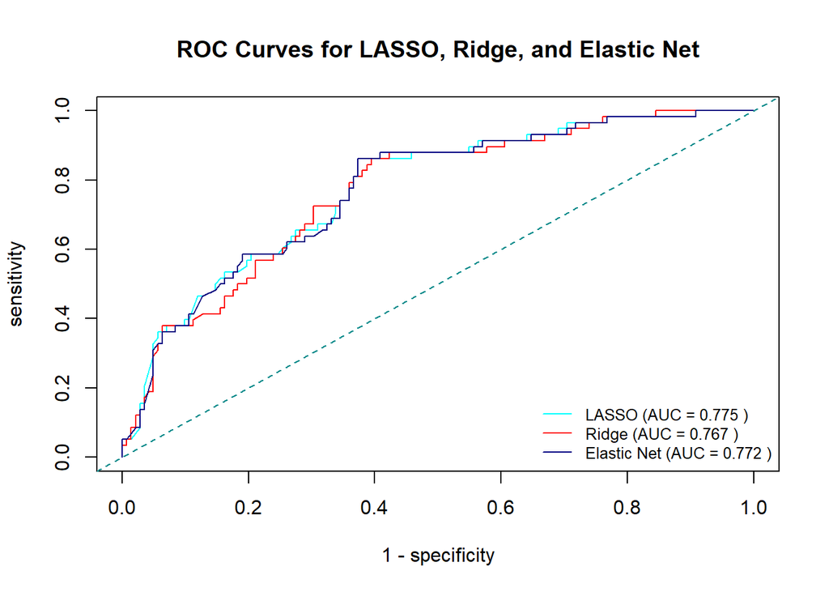

```r
# library(pROC)
# Predicted probabilities for each model: type = "response"
prob_lasso <- predict(lasso_model_opt, newx = X_test, type = "response")
prob_ridge <- predict(ridge_model_opt, newx = X_test, type = "response")
prob_elastic <- predict(elastic_model_opt, newx = X_test, type = "response")

# Compute ROC curves: roc object contains a lot information including
# sensitivity, specificity, AUC, etc.
roc_lasso <- roc(y_test, prob_lasso)
roc_ridge <- roc(y_test, prob_ridge)
roc_elastic <- roc(y_test, prob_elastic)

# Compute AUC values
auc_lasso <- auc(roc_lasso)
auc_ridge <- auc(roc_ridge)
auc_elastic <- auc(roc_elastic)

## LASSO
sen.lasso <- roc_lasso$sensitivities
spe.lasso <- roc_lasso$specificities
auc.lasso <- roc_lasso$auc

## Ridge
sen.ridge <- roc_ridge$sensitivities
spe.ridge <- roc_ridge$specificities
auc.ridge <- roc_ridge$auc

## Elastic Net
sen.elastic <- roc_elastic$sensitivities
spe.elastic <- roc_elastic$specificities
auc.elastic <- roc_elastic$auc

## Plotting the ROC curves: three colors - green, orange, and purple

plot(1-spe.lasso, sen.lasso,
     type = "l",
     col = "cyan",
     xlim=c(0,1),
     xlab = "1 - specificity",
     ylab = "sensitivity",
     main = "ROC Curves for LASSO, Ridge, and Elastic Net")
lines(1-spe.ridge, sen.ridge, col = "red")
lines(1-spe.elastic, sen.elastic, col = "navy")
abline(0,1, type = "l", lty = 2, col = "cyan4", lwd = 1)

# Add legend
legend("bottomright", legend = c(paste("LASSO (AUC =", round(auc_lasso, 3), ")"),
                                paste("Ridge (AUC =", round(auc_ridge, 3), ")"),
                                paste("Elastic Net (AUC =", round(auc_elastic, 3), ")")),
       col = c("cyan", "red", "navy"), lty = 1, cex = 0.8, bty = "n")
```

## 4.5 Model Selection of Regularized Regression

**Recommendation**: Considering the fact the the 3 are almost equaly well performed, I would recommend using Lasso since it is easier to implement and explain to other. it is also more suited for large data set such as the communication company.

# 5 Calculating The Churn Using SVM For Binary Classifiction

## 5.1 Confusion Matrix

```r
# Install and load the e1071 package
library(e1071)

##
## two-way data splitting
set.seed(123456)    # For reproducibility
index <- sample(1:nrow(data), 0.8 * nrow(data))
train.data <- data[index, ]
test.data <- data[-index, ]
##
## Set up custom cross-validation control
tune_control <- tune.control(
  cross = 5,  # Use 5-fold cross-validation, the default is 10-fold cross-validation
  nrepeat = 1 # Number of repetitions (for repeated cross-validation)
)
##
## Perform a grid search for the best hyperparameters
tune.RBF <- tune(
  svm,          # using the primary svm() algorithm to tune parameter
  Churn ~ ., # model formula
  data = train.data,
  kernel = "radial",    # You can change the kernel if needed
  ranges = list(
    cost = 10^(-1:2),   # tune the hyperparameter C in the loss function
    gamma = c(0.1, 0.5, 1, 2)  # the hyper parameter in the RBF kernel
  ),
  tunecontrol = tune_control  # Use custom cross-validation settings
)
# Print the tuning results for inspection
# print(tune_result)
##
## Extract the best model and hyperparameters
best.RBF <- tune.RBF$best.model
best.cost.RBF <- best.RBF$cost
best.gamma.RBF <- best.RBF$gamma

# Print the best hyperparameters onor inspection
# cat("Best Cost:", best_cost, "\n")
# cat("Best Gamma:", best_gamma, "\n")
##
## Train the final SVM model with the best hyperparameters
final.RBF.class <- svm(
  Churn ~ .,
  data = train.data,
  kernel = "radial",
  cost = best.cost.RBF,
  gamma = best.gamma.RBF,
   type = "C-classification"
)

# Print the final model - for inspection
# print(final_model)
##
## Make predictions on the test set: type = "class"
pred.RBF.class <- predict(final.RBF.class, test.data, type = "class")

# Evaluate the predictions (e.g., using a confusion matrix)-Using default cutoff 0.5
confusion.matrix.RBF <- table(Predicted = pred.RBF.class, Actual = test.data$Churn)
print(confusion.matrix.RBF)
```

```
         Actual
Predicted   0   1
        0 128  34
        1  14  24
```

## 5.2 Calculating Accuracy

```r
# Calculate accuracy
accuracy <- sum(diag(confusion.matrix.RBF)) / sum(confusion.matrix.RBF)
cat("\n\n Accuracy:", accuracy, "\n")
```

```
 Accuracy: 0.76
```

## 5.3 Calculating AUC and showing Area Under the Curve AUC

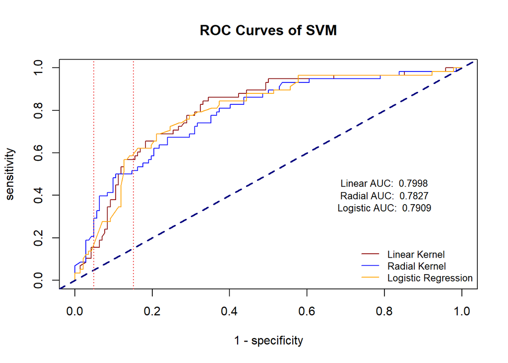

```r
##


train.data$Churn <- as.numeric(as.character(train.data$Churn))
test.data$Churn <- as.numeric(as.character(test.data$Churn))

## Set up custom cross-validation control
tune.control <- tune.control(
  cross = 5,  # Use 5-fold cross-validation, the default is 10-fold cross-validation
  nrepeat = 1 # Number of repetitions (for repeated cross-validation)
)
##
## Perform a grid search for the best hyperparameters
tune.lin <- tune(
  svm,          # using the primary svm() algorithm to tune parameter
  Churn ~ ., # model formula
  data = train.data,
  kernel = "linear",    # You can change the kernel if needed
  ranges = list(
    cost = 10^(-1:2)   # tune the hyperparameter C in the loss function
  ),
  tunecontrol = tune.control  # Use custom cross-validation settings
)
# Print the tuning results for inspection
# print(tune_result)
##
## Extract the best model and hyperparameters
best.lin <- tune.lin$best.model
best.cost.lin <- best.lin$cost
# Print the best hyperparameters for inspection
# cat("Best Cost:", best_cost, "\n")
# cat("Best Gamma:", best_gamma, "\n")
##
## Train the final SVM model with the best hyperparameters
final.lin <- svm(
  Churn ~ .,
  data = train.data,
  kernel = "linear",
  cost = best.cost.lin,
  probability = TRUE,
   type = "C-classification"
)

## Request to return probabilities in final.RBF

final.RBF <- svm(
  Churn ~ .,
  data = train.data,
  kernel = "radial",
  cost = best.cost.RBF,
  gamma = best.gamma.RBF,
  probability = TRUE,
   type = "C-classification"
)
########################
###  logistic regression
logit.fit <- glm(Churn ~ ., data = train.data, family = binomial)
AIC.logit <- step(logit.fit, direction = "both", trace = 0)
pred.logit <- predict(AIC.logit, test.data, type = "response")

###
####################
# ROC Curve and AUC
pred.prob.lin <- predict(final.lin, test.data, probability = TRUE)
pred.prob.RBF <- predict(final.RBF, test.data, probability = TRUE)
##
## extracting probabilities
prob.linear <- attr(pred.prob.lin, "probabilities")[, 2]
prob.radial <- attr(pred.prob.RBF, "probabilities")[, 2]
###
roc_lin <- roc(test.data$Churn, prob.linear)
roc_RBF <- roc(test.data$Churn, prob.radial)
roc_logit <- roc(test.data$Churn, pred.logit)
### Sen-Spe
lin.sen <- roc_lin$sensitivities
lin.spe <- roc_lin$specificities
rad.sen <- roc_RBF$sensitivities
rad.spe <- roc_RBF$specificities
logit.sen <- roc_logit$sensitivities
logit.spe <- roc_logit$specificities
## AUC
auc.lin <- roc_lin$auc
auc.rad <- roc_RBF$auc
auc.logit <- roc_logit$auc
## Plotting ROC curves

plot(1-lin.spe, lin.sen,
     xlab = "1 - specificity",
     ylab = "sensitivity",
     col = "darkred",
     type = "l",
     lty = 1,
     lwd = 1,
     main = "ROC Curves of SVM")
lines(1-rad.spe, rad.sen,
      col = "blue",
      lty = 1,
      lwd = 1)
lines(1-logit.spe, logit.sen,
      col = "orange",
      lty = 1,
      lwd = 1)
abline(0,1, col = "navy", lty = 2, lwd = 2)
abline(v=c(0.049,0.151), lty = 3, col = "brown2")
legend("bottomright", c("Linear Kernel", "Radial Kernel", "Logistic Regression"),
       lty = c(1,1,1), lwd = rep(1,3),
       col = c("darkred", "blue", "orange"),
       bty="n",cex = 0.8)
## annotation - AUC
text(0.8, 0.46, paste("Linear AUC: ", round(auc.lin,4)), cex = 0.8)
text(0.8, 0.4, paste("Radial AUC: ", round(auc.rad,4)), cex = 0.8)
text(0.8, 0.34, paste("Logistic AUC: ", round(auc.logit,4)), cex = 0.8)
```

# 6 Conclusion